# DS Lab 3: Exploring Happiness

Due: Thursday 10/03/2019 by 10 pm

Jennie Huxford and Carlos

09/26/2019

```r
Happy <- readRDS("HAPPY.rds")
head(Happy)
```

```
##           HAPPY YEAR AGE    SEX       MARITAL         DEGREE       FINRELA
## 1 NOT TOO HAPPY 1972  23 FEMALE NEVER MARRIED       BACHELOR       AVERAGE
## 2 NOT TOO HAPPY 1972  70   MALE       MARRIED LT HIGH SCHOOL ABOVE AVERAGE
## 3  PRETTY HAPPY 1972  48 FEMALE       MARRIED    HIGH SCHOOL       AVERAGE
## 4 NOT TOO HAPPY 1972  27 FEMALE       MARRIED       BACHELOR       AVERAGE
## 5  PRETTY HAPPY 1972  61 FEMALE       MARRIED    HIGH SCHOOL ABOVE AVERAGE
## 6  PRETTY HAPPY 1972  26   MALE NEVER MARRIED    HIGH SCHOOL ABOVE AVERAGE
##      HEALTH WTSSALL          PARTYID POLVIEWS
## 1      GOOD  0.4446     IND,NEAR DEM      IAP
## 2      FAIR  0.8893 NOT STR DEMOCRAT      IAP
## 3 EXCELLENT  0.8893      INDEPENDENT      IAP
## 4      GOOD  0.8893 NOT STR DEMOCRAT      IAP
## 5      GOOD  0.8893  STRONG DEMOCRAT      IAP
## 6      GOOD  0.4446     IND,NEAR DEM      IAP
```

```r
names(Happy) = tolower(names(Happy))
names(Happy)
```

```
##  [1] "happy"    "year"     "age"      "sex"      "marital"  "degree"
##  [7] "finrela"  "health"   "wtssall"  "partyid"  "polviews"
```

# Report

Data cleaning: the values “IAP”, “DK” and “NA” all encode missing values. We have replaced all of these instances by the value `NA`.

```r
Happy[Happy=="IAP"]=NA
Happy[Happy=="NA"]=NA
Happy[Happy=="DK"]=NA
head(Happy)
```

```
##           happy year age    sex       marital         degree       finrela
## 1 NOT TOO HAPPY 1972  23 FEMALE NEVER MARRIED       BACHELOR       AVERAGE
## 2 NOT TOO HAPPY 1972  70   MALE       MARRIED LT HIGH SCHOOL ABOVE AVERAGE
## 3  PRETTY HAPPY 1972  48 FEMALE       MARRIED    HIGH SCHOOL       AVERAGE
## 4 NOT TOO HAPPY 1972  27 FEMALE       MARRIED       BACHELOR       AVERAGE
## 5  PRETTY HAPPY 1972  61 FEMALE       MARRIED    HIGH SCHOOL ABOVE AVERAGE
## 6  PRETTY HAPPY 1972  26   MALE NEVER MARRIED    HIGH SCHOOL ABOVE AVERAGE
##      health wtssall          partyid polviews
## 1      GOOD  0.4446     IND,NEAR DEM     <NA>
## 2      FAIR  0.8893 NOT STR DEMOCRAT     <NA>
## 3 EXCELLENT  0.8893      INDEPENDENT     <NA>
## 4      GOOD  0.8893 NOT STR DEMOCRAT     <NA>
## 5      GOOD  0.8893  STRONG DEMOCRAT     <NA>
## 6      GOOD  0.4446     IND,NEAR DEM     <NA>
```

We have changed the age of “89 OR OLDER” to 89 and changed the variable to numeric. Cast categorical variables to factor.

```r
unique(Happy$age)
```

```
##  [1] "23"          "70"          "48"          "27"          "61"
##  [6] "26"          "28"          "21"          "30"          "56"
## [11] "54"          "49"          "41"          "24"          "62"
## [16] "46"          "57"          "58"          "71"          "53"
## [21] "42"          "20"          "25"          "78"          "35"
## [26] "51"          "76"          "39"          "64"          "50"
## [31] "40"          "43"          "37"          "22"          "31"
## [36] "52"          "47"          "45"          "68"          "63"
## [41] "19"          "55"          "44"          "34"          "36"
## [46] "74"          "69"          "29"          "67"          "75"
## [51] "38"          "73"          "84"          "82"          "72"
## [56] "59"          "33"          "81"          "65"          "32"
## [61] NA            "60"          "80"          "66"          "77"
## [66] "18"          "79"          "83"          "85"          "88"
## [71] "87"          "89 OR OLDER" "86"
```

```r
Happy$age[Happy$age=="89 OR OLDER"] <- '89'
unique(Happy$age)
```

```
##  [1] "23" "70" "48" "27" "61" "26" "28" "21" "30" "56" "54" "49" "41" "24"
## [15] "62" "46" "57" "58" "71" "53" "42" "20" "25" "78" "35" "51" "76" "39"
## [29] "64" "50" "40" "43" "37" "22" "31" "52" "47" "45" "68" "63" "19" "55"
## [43] "44" "34" "36" "74" "69" "29" "67" "75" "38" "73" "84" "82" "72" "59"
## [57] "33" "81" "65" "32" NA   "60" "80" "66" "77" "18" "79" "83" "85" "88"
## [71] "87" "89" "86"
```

```r
Happy$age <- as.numeric(Happy$age)
typeof(Happy$age)
```

```
## [1] "double"
```

```r
Happy$degree <- as.factor(Happy$degree)
Happy$happy <- as.factor(Happy$happy)
Happy$sex <- as.factor(Happy$sex)
Happy$finrela <- as.factor(Happy$finrela)
Happy$health <- as.factor(Happy$health)
head(Happy)
```

```
##           happy year age    sex       marital         degree       finrela
## 1 NOT TOO HAPPY 1972  23 FEMALE NEVER MARRIED       BACHELOR       AVERAGE
## 2 NOT TOO HAPPY 1972  70   MALE       MARRIED LT HIGH SCHOOL ABOVE AVERAGE
## 3  PRETTY HAPPY 1972  48 FEMALE       MARRIED    HIGH SCHOOL       AVERAGE
## 4 NOT TOO HAPPY 1972  27 FEMALE       MARRIED       BACHELOR       AVERAGE
## 5  PRETTY HAPPY 1972  61 FEMALE       MARRIED    HIGH SCHOOL ABOVE AVERAGE
## 6  PRETTY HAPPY 1972  26   MALE NEVER MARRIED    HIGH SCHOOL ABOVE AVERAGE
##      health wtssall          partyid polviews
## 1      GOOD  0.4446     IND,NEAR DEM     <NA>
## 2      FAIR  0.8893 NOT STR DEMOCRAT     <NA>
## 3 EXCELLENT  0.8893      INDEPENDENT     <NA>
## 4      GOOD  0.8893 NOT STR DEMOCRAT     <NA>
## 5      GOOD  0.8893  STRONG DEMOCRAT     <NA>
## 6      GOOD  0.4446     IND,NEAR DEM     <NA>
```

We have reordered marital by age.

```r
Happy$marital <- factor(Happy$marital, levels = c("NEVER MARRIED", "MARRIED", "SEPARATED", "DIVORCED", "WIDOWED"))
Happy$marital <- order(Happy$marital, Happy$age)
```

We also reordered degree by the order of which you would go about obtaining each degree.

```r
Happy$degree <- factor(Happy$degree, levels = c("LT HIGH SCHOOL", "HIGH SCHOOL", "JUNIOR COLLEGE", "BACHELOR", "GRADUATE"))
table(Happy$degree)
```

```
##
## LT HIGH SCHOOL    HIGH SCHOOL JUNIOR COLLEGE       BACHELOR       GRADUATE
##          13325          32017           3472           9010           4469
```

Then we reordered health from the worst health, poor, to the best health, excellent.

```r
Happy$health <- factor(Happy$health, levels = c("POOR", "FAIR", "GOOD", "EXCELLENT"))
table(Happy$health)
```

```
##
##      POOR      FAIR      GOOD EXCELLENT
##      2638      8768     20788     13827
```

We decided to look at the overall distributions of the variables degree and happy.

### Distribution of degree:

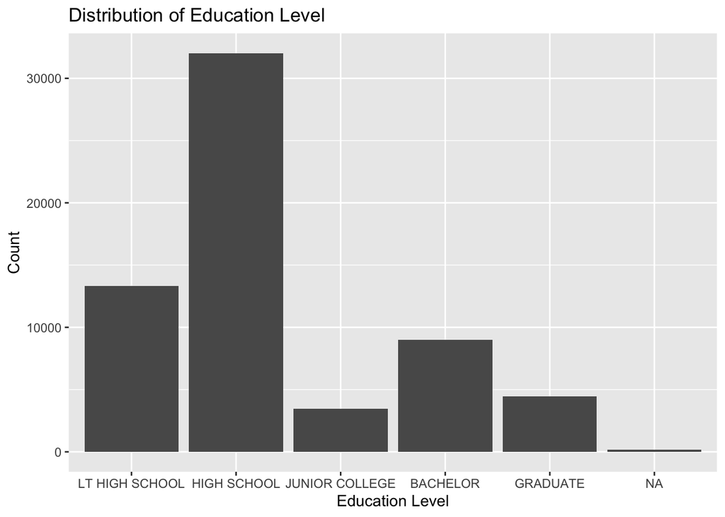

```r
library(ggplot2)
ggplot(data = Happy, aes(x=degree)) +
  geom_bar() +
  ggtitle("Distribution of Education Level") +
  xlab("Education Level") +
  ylab("Count")
```

```r
prop.table(table(Happy$degree))
```

```
##
## LT HIGH SCHOOL    HIGH SCHOOL JUNIOR COLLEGE       BACHELOR       GRADUATE
##     0.21390846     0.51397428     0.05573660     0.14463904     0.07174161
```

When focussing on degree the data shows us that people with a high school degree as their highest level of education is greater than any other level of degree while, people with a junior collegiate degree as their highest level of education is lower than any other degree level.

### Distribution of Happy

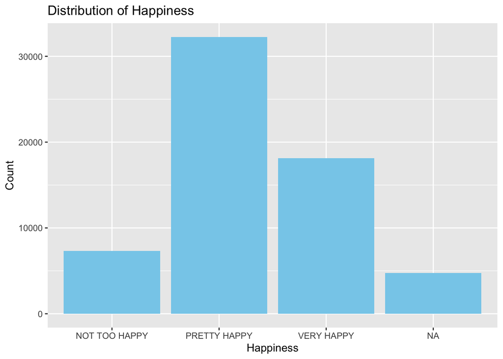

```r
ggplot(data = Happy, aes(x = happy, color = marital)) +
  geom_bar(fill = "sky blue")+
  ggtitle("Distribution of Happiness") +
  xlab("Happiness") +
  ylab("Count")
```

```r
prop.table(table(Happy$happy))
```

```
##
## NOT TOO HAPPY  PRETTY HAPPY    VERY HAPPY
##     0.1270490     0.5589326     0.3140184
```

Looking at happiness overall we see that about 55% of people are “Pretty Happy”, only about 12% of people are “Not Too Happy”, and the remaining 31% are “Very Happy.”

## We then investigated if happiness had a relationship with degree, health and/or sex.

### Relationship between Happiness and degree

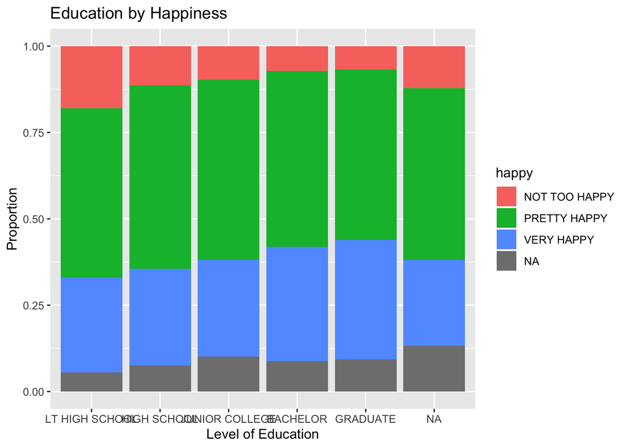

```r
ggplot(data = Happy, aes(x = degree, fill= happy)) +
  geom_bar(position = "fill") +
  ggtitle("Education by Happiness") +
  xlab("Level of Education") +
  ylab("Proportion")
```

### Relationship between Happiness and Sex

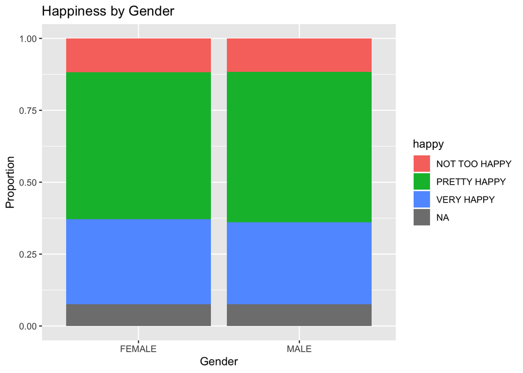

```r
ggplot(data = Happy, aes(x = sex, fill = happy)) +
  geom_bar(position = 'fill') +
  ggtitle("Happiness by Gender") +
  xlab("Gender") +
  ylab("Proportion")
```

### Relationship between Healthiness and Happiness

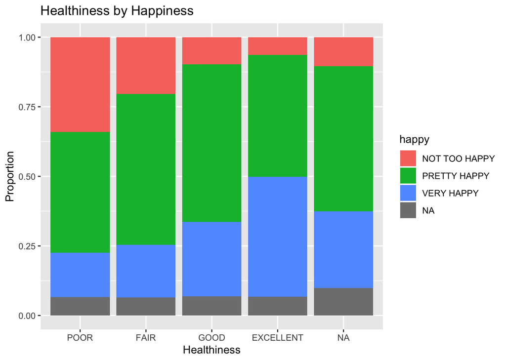

```r
ggplot(data = Happy, aes(x = health, fill = happy )) +
  geom_bar(position = 'fill') +
  ggtitle("Healthiness by Happiness") +
  xlab("Healthiness") +
  ylab("Proportion")
```

———– END OF REPORT —————-

## Work done before putting report together

- We will check whether or not your lab results are reproducible - i.e. we will knit your `team.Rmd` file.
- At this point, you should be pretty familar with using Rmarkdown and explored its various features. Starting from this assignment, you will also be graded on **style**. Style means is your report *clear, easy to read, and flows logically*? Is it obvious that you and your partner have spent time organizing the material in a compelling way that makes it easy (and even enjoyable) for others to read? This `team.Rmd` should be something that you would feel confident turning into a manager/supervisor as proof of your progress.
- Each plot at **minimum** must have labels for both axes and a title. If you don’t have these components, you will not get full credit for your answers. Each plot ideally should also come with a description.

## Background

The General Social Survey (GSS) has been run by NORC every other year since 1972 to keep track of current opinions across the United States.

An excerpt of the GSS data is available from my github website.

```r
Happy <- readRDS("HAPPY.rds")
head(Happy)
```

```
##           HAPPY YEAR AGE    SEX       MARITAL         DEGREE       FINRELA
## 1 NOT TOO HAPPY 1972  23 FEMALE NEVER MARRIED       BACHELOR       AVERAGE
## 2 NOT TOO HAPPY 1972  70   MALE       MARRIED LT HIGH SCHOOL ABOVE AVERAGE
## 3  PRETTY HAPPY 1972  48 FEMALE       MARRIED    HIGH SCHOOL       AVERAGE
## 4 NOT TOO HAPPY 1972  27 FEMALE       MARRIED       BACHELOR       AVERAGE
## 5  PRETTY HAPPY 1972  61 FEMALE       MARRIED    HIGH SCHOOL ABOVE AVERAGE
## 6  PRETTY HAPPY 1972  26   MALE NEVER MARRIED    HIGH SCHOOL ABOVE AVERAGE
##      HEALTH WTSSALL          PARTYID POLVIEWS
## 1      GOOD  0.4446     IND,NEAR DEM      IAP
## 2      FAIR  0.8893 NOT STR DEMOCRAT      IAP
## 3 EXCELLENT  0.8893      INDEPENDENT      IAP
## 4      GOOD  0.8893 NOT STR DEMOCRAT      IAP
## 5      GOOD  0.8893  STRONG DEMOCRAT      IAP
## 6      GOOD  0.4446     IND,NEAR DEM      IAP
```

Converted all names to lowercase, becasue it is easier to work with.

```r
names(Happy) = tolower(names(Happy))
names(Happy)
```

```
##  [1] "happy"    "year"     "age"      "sex"      "marital"  "degree"
##  [7] "finrela"  "health"   "wtssall"  "partyid"  "polviews"
```

Now it’s important to understand what each column stands for. You can find a codebook with explanations for each of the variables at https://gssdataexplorer.norc.org/

## Part one (cleaning)

Answer each of the following questions using R code to get an answer.

Write a separate code chunk to manipulate each variable. Once all the data manipulation is done, show the values in a barchart or histogram and comment on the plot. Use `ggplot2` to create the plots.

1. Data cleaning: the values “IAP”, “DK” and “NA” all encode missing values. We have replaced all of these instances by the value `NA`.

```r
Happy[Happy=="IAP"]=NA
Happy[Happy=="NA"]=NA
Happy[Happy=="DK"]=NA
head(Happy)
```

```
##           happy year age    sex       marital         degree       finrela
## 1 NOT TOO HAPPY 1972  23 FEMALE NEVER MARRIED       BACHELOR       AVERAGE
## 2 NOT TOO HAPPY 1972  70   MALE       MARRIED LT HIGH SCHOOL ABOVE AVERAGE
## 3  PRETTY HAPPY 1972  48 FEMALE       MARRIED    HIGH SCHOOL       AVERAGE
## 4 NOT TOO HAPPY 1972  27 FEMALE       MARRIED       BACHELOR       AVERAGE
## 5  PRETTY HAPPY 1972  61 FEMALE       MARRIED    HIGH SCHOOL ABOVE AVERAGE
## 6  PRETTY HAPPY 1972  26   MALE NEVER MARRIED    HIGH SCHOOL ABOVE AVERAGE
##      health wtssall          partyid polviews
## 1      GOOD  0.4446     IND,NEAR DEM     <NA>
## 2      FAIR  0.8893 NOT STR DEMOCRAT     <NA>
## 3 EXCELLENT  0.8893      INDEPENDENT     <NA>
## 4      GOOD  0.8893 NOT STR DEMOCRAT     <NA>
## 5      GOOD  0.8893  STRONG DEMOCRAT     <NA>
## 6      GOOD  0.4446     IND,NEAR DEM     <NA>
```

2. For age, we have changed “89 OR OLDER” to 89 and changed the variable to numeric. Cast categorical variables to factor.

```r
unique(Happy$age)
```

```
##  [1] "23"          "70"          "48"          "27"          "61"
##  [6] "26"          "28"          "21"          "30"          "56"
## [11] "54"          "49"          "41"          "24"          "62"
## [16] "46"          "57"          "58"          "71"          "53"
## [21] "42"          "20"          "25"          "78"          "35"
## [26] "51"          "76"          "39"          "64"          "50"
## [31] "40"          "43"          "37"          "22"          "31"
## [36] "52"          "47"          "45"          "68"          "63"
## [41] "19"          "55"          "44"          "34"          "36"
## [46] "74"          "69"          "29"          "67"          "75"
## [51] "38"          "73"          "84"          "82"          "72"
## [56] "59"          "33"          "81"          "65"          "32"
## [61] NA            "60"          "80"          "66"          "77"
## [66] "18"          "79"          "83"          "85"          "88"
## [71] "87"          "89 OR OLDER" "86"
```

```r
Happy$age[Happy$age=="89 OR OLDER"] <- '89'
Happy$age <- as.numeric(Happy$age)
typeof(Happy$age)
```

```
## [1] "double"
```

```r
Happy$degree <- as.factor(Happy$degree)
Happy$happy <- as.factor(Happy$happy)
Happy$sex <- as.factor(Happy$sex)
Happy$finrela <- as.factor(Happy$finrela)
Happy$health <- as.factor(Happy$health)
```

3. Bring all levels of factors into a sensible order. For marital you could e.g. order the levels according to average age.

```r
age<- Happy$age
marital<- Happy$marital
sex<- Happy$sex
health <- Happy$health
```

We have reordered marital. We also ordered marital by age.

```r
Happy$marital <- factor(Happy$marital, levels = c("NEVER MARRIED", "MARRIED", "SEPARATED", "DIVORCED", "WIDOWED"))
Happy$marital <- order(marital, age)
```

We also reordered degree by the order of which you would go about obtaining each degree.

```r
Happy$degree <- factor(Happy$degree, levels = c("LT HIGH SCHOOL", "HIGH SCHOOL", "JUNIOR COLLEGE", "BACHELOR", "GRADUATE"))
```

Then we reordered health from the worst health, poor, to the best health, excellent.

```r
Happy$health <- factor(Happy$health, levels = c("POOR", "FAIR", "GOOD", "EXCELLENT"))
```

## Part two (exploration)

*Happiness!* Use `ggplot2` to create the plots. Your exploration should make use all elements of the grammar of graphics: mappings (`color`, `fill`, and `size` at least), different `geom`s (4 at least), scales, coordinates (eg `coord_flip`), facet, and theme (eg setting axis labels and title). **The final plot doesn’t need to include all these elements, but they should be part of your exploration**. For each investigation, create an appropriate visualization and write a paragraph to describe it.

1. Investigate the distributions of 2 different variables.

```r
library(tidyverse)
```

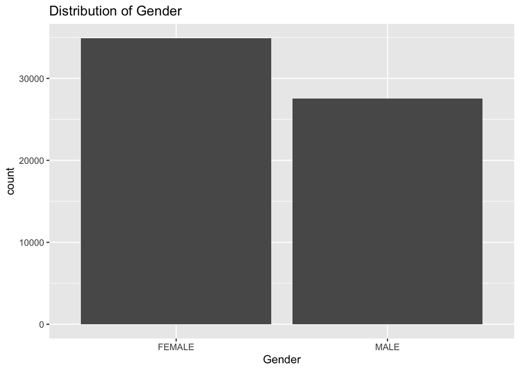

```r
ggplot(data = Happy, aes(x=sex)) +
  geom_bar() +
  ggtitle("Distribution of Gender") +
  xlab("Gender")
```

```r
prop.table(table(Happy$sex))
```

```
##
##   FEMALE     MALE
## 0.558768 0.441232
```

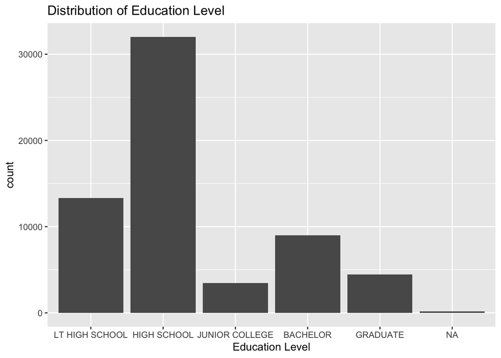

```r
ggplot(data = Happy, aes(x=degree)) +
  geom_bar() +
  ggtitle("Distribution of Education Level") +
  xlab("Education Level")
```

```r
table(Happy$degree)
```

```
##
## LT HIGH SCHOOL    HIGH SCHOOL JUNIOR COLLEGE       BACHELOR       GRADUATE
##          13325          32017           3472           9010           4469
```

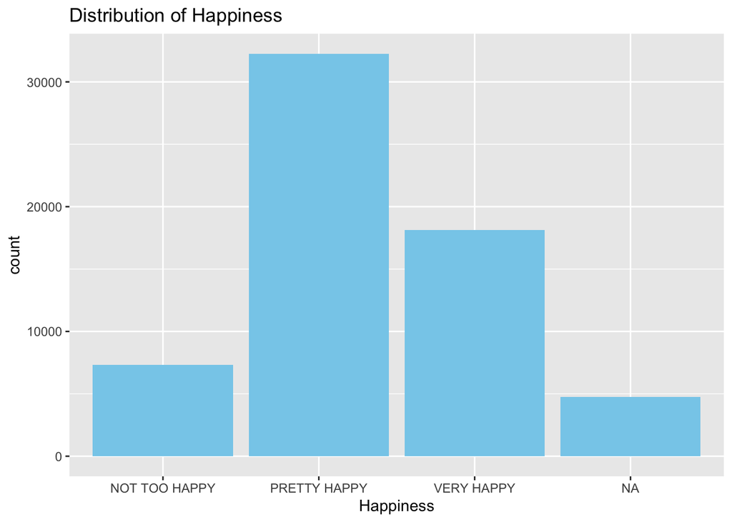

```r
ggplot(data = Happy, aes(x = happy, color = marital)) +
  geom_bar(fill = "sky blue")+
  ggtitle("Distribution of Happiness") +
  xlab("Happiness")
```

```r
prop.table(table(Happy$happy))
```

```
##
## NOT TOO HAPPY  PRETTY HAPPY    VERY HAPPY
##     0.1270490     0.5589326     0.3140184
```

2. Investigate the relationship between happiness and three other variables in the data.

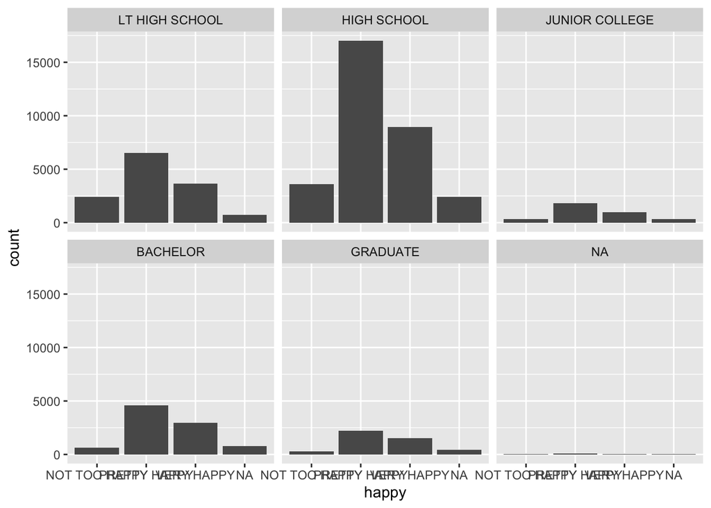

```r
#relationship between happy and degree
ggplot(data = Happy, aes(x = happy)) +
  geom_bar() +
  facet_wrap(~degree)
```

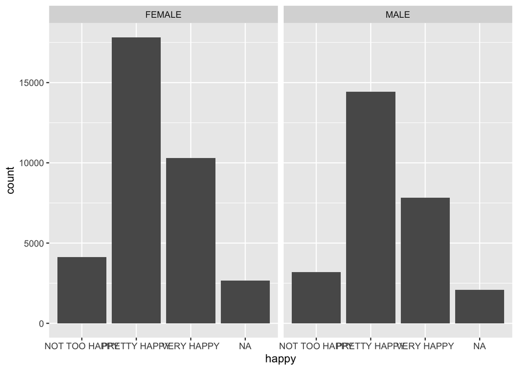

```r
#relationship between happy and sex
ggplot(data = Happy, aes(x = happy)) +
  geom_bar() +
  facet_wrap("sex")
```

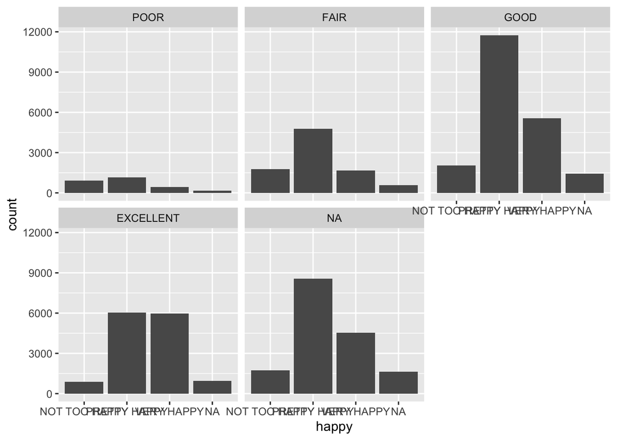

```r
#relationship between happiness and health
ggplot(data = Happy, aes(x = happy)) +
  geom_bar() +
  facet_wrap("health")
```

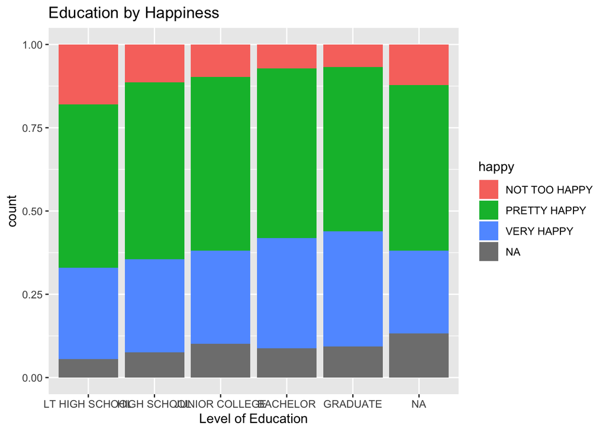

```r
ggplot(data = Happy, aes(x = degree, fill= happy)) +
  geom_bar(position = "fill") +
  ggtitle("Education by Happiness") +
  xlab("Level of Education")
```

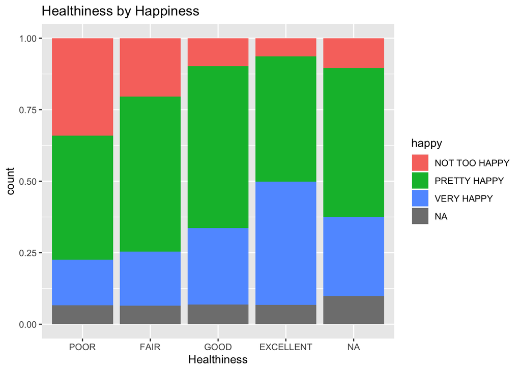

```r
ggplot(data = Happy, aes(x = health, fill = happy )) +
  geom_bar(position = 'fill') +
  ggtitle("Healthiness by Happiness") +
  xlab("Healthiness")
```

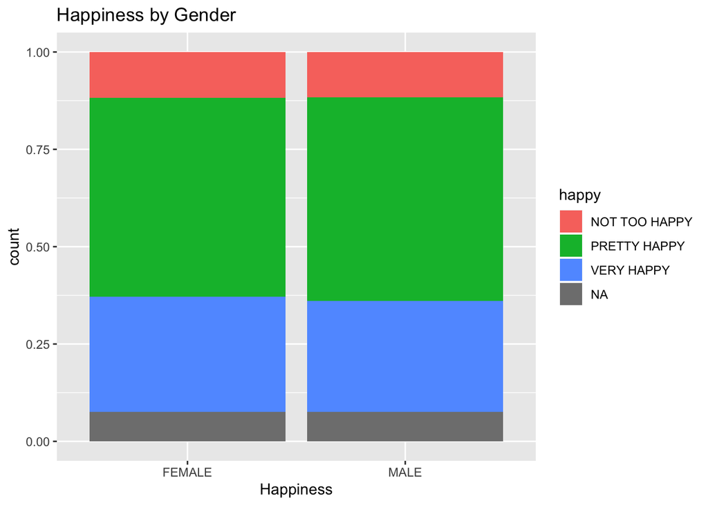

```r
ggplot(data = Happy, aes(x = sex, fill = happy)) +
  geom_bar(position = 'fill') +
  ggtitle("Happiness by Gender") +
  xlab("Happiness")
```

3. What do you learn from the data set? Write one or two paragraphs to describe. When focussing on degree the data shows us that people with a high school degree as their highest level of education is greater than any other level of degree while, people with a junior collegiate degree as their highest level of education is lower than any other degree level. Looking at happiness overall we see that about 55% of people are “Pretty Happy”, only about 12% of people are “Not Too Happy”, and the remaining 31% are “Very Happy.”

```
- The owner's GitHub username

- The partner's GitHub username

- Repo name (should be `ds202_lab3`)
```